# Ontogenetic change in conodont elements

- Show All Code
- Hide All Code
- View Source

Comparison of linear, two-line, and three-line broken-stick models

Author

Humberto G. Ferrón Jiménez

Published

July 14, 2026

# 1 Biological background

The dataset represents a **population of conodont elements spanning different ontogenetic stages**. Two variables were measured for each element:

- **element length**, used as a proxy for body or element size;
- **number of denticles on the blade**, a meristic character that may change during ontogeny.

The biological objective is to determine whether the relationship between these variables is best represented by:

1. a single continuous growth trajectory;
2. two ontogenetic phases separated by one transition; or
3. three ontogenetic phases separated by two transitions.

During ontogeny, denticles may be added rapidly in small elements, more slowly during an intermediate stage, and cease to be added once the adult denticulation pattern has been established. If so, the relationship between length and denticle number should show successive reductions in slope.

# 2 Hypotheses and predictions

## 2.1 Model 1: a single linear trajectory

The simplest hypothesis proposes one constant relationship across the full size range:

[ y_i=_0+_1x_i+_i. ]

Under this model, denticle number changes at the same average rate throughout ontogeny. There is no detectable juvenile–adult transition based on these two characters.

## 2.2 Model 2: two ontogenetic phases

A broken-stick model with one breakpoint represents two connected linear phases:

[ y_i=_0+_1x_i+ _2(x_i-*1)*+ + _i. ]

This model is compatible with:

1. a juvenile phase in which length and denticle number increase together;
2. an adult phase in which denticle addition slows or stops.

The prediction is a positive first slope followed by a much smaller second slope.

## 2.3 Model 3: three ontogenetic phases

A broken-stick model with two breakpoints represents three connected linear phases:

[ y_i=_0+_1x_i+ _2(x_i-*1)*+ +_3(x_i-*2)*+ +_i. ]

This model is compatible with:

1. an **early juvenile phase** with rapid denticle addition;
2. a **late juvenile or subadult phase** with slower denticle addition;
3. an **adult phase** in which denticle number approaches a plateau.

The principal prediction is a progressive reduction in slope across the three phases.

**Scope of inference**

Broken-stick regression identifies changes in the mean ontogenetic trajectory. It does not perform unsupervised clustering and does not demonstrate that juveniles, subadults, and adults form perfectly discrete groups.

The breakpoints should therefore be regarded as **candidate ontogenetic thresholds**. Independent morphological, histological, or growth-related evidence is required to validate them as actual maturity boundaries.

# 3 Analytical objective

The three models are compared using:

- AIC and sample-size-corrected AIC (AICc);
- Bayesian information criterion (BIC);
- Akaike weights;
- root mean squared error (RMSE);
- (R^2);
- the estimated slopes and breakpoints;
- residual diagnostics.

AICc is used as the primary model-selection criterion because the candidate models differ in complexity and because the additional breakpoints must be justified by sufficient improvement in fit. BIC is reported as a more conservative criterion that penalises additional parameters more strongly.

# 4 Analysis setup

**Show R code**

```r
required_packages <- c(
  "readxl",
  "ggplot2",
  "segmented",
  "patchwork",
  "knitr"
)

missing_packages <- setdiff(
  required_packages,
  rownames(installed.packages())
)

if (length(missing_packages) > 0) {
  install.packages(missing_packages)
}

invisible(
  lapply(
    required_packages,
    library,
    character.only = TRUE
  )
)

options(
  scipen = 999,
  digits = 6
)

set.seed(123)

fmt <- function(x, digits = 2) {
  formatC(
    x,
    format = "f",
    digits = digits,
    decimal.mark = "."
  )
}
```

# 5 Importing and preparing the data

**Show R code**

```r
file_path <- params$data_file
sheet_to_read <- params$sheet
output_dir <- dirname(file_path)

if (!file.exists(file_path)) {
  stop(
    paste0(
      "The input file was not found:\n",
      file_path,
      "\n\nEdit params$data_file in the YAML header."
    )
  )
}

raw_data <- readxl::read_excel(
  path = file_path,
  sheet = sheet_to_read
)

if (ncol(raw_data) < 3) {
  stop(
    "The input file must contain at least three columns: ID, Length, and Denticles."
  )
}

dat <- data.frame(
  ID = raw_data[[1]],
  Length = suppressWarnings(
    as.numeric(raw_data[[2]])
  ),
  Denticles = suppressWarnings(
    as.numeric(raw_data[[3]])
  )
)

n_original <- nrow(dat)

dat <- dat[
  complete.cases(
    dat[, c("Length", "Denticles")]
  ),
]

n_removed <- n_original - nrow(dat)

if (nrow(dat) < 20) {
  stop(
    "There are too few complete observations for a reliable three-model comparison."
  )
}

if (length(unique(dat$Length)) < 10) {
  stop(
    "There are too few unique Length values."
  )
}

data_summary <- data.frame(
  Variable = c(
    "Observations analysed",
    "Rows removed because of missing/non-numeric values",
    "Minimum element length",
    "Maximum element length",
    "Minimum denticle number",
    "Maximum denticle number"
  ),
  Value = c(
    nrow(dat),
    n_removed,
    min(dat$Length),
    max(dat$Length),
    min(dat$Denticles),
    max(dat$Denticles)
  )
)

knitr::kable(
  data_summary,
  digits = 3,
  caption = "Summary of the dataset included in the analysis."
)
```

Summary of the dataset included in the analysis.

| Variable | Value |
| --- | --- |
| Observations analysed | 374.000 |
| Rows removed because of missing/non-numeric values | 0.000 |
| Minimum element length | 198.088 |
| Maximum element length | 754.995 |
| Minimum denticle number | 5.000 |
| Maximum denticle number | 12.000 |

A total of **374 complete observations** are included. Denticle number is an integer count, although the primary analyses use Gaussian least-squares regression as a descriptive approximation.

# 6 Exploratory relationship

**Show R code**

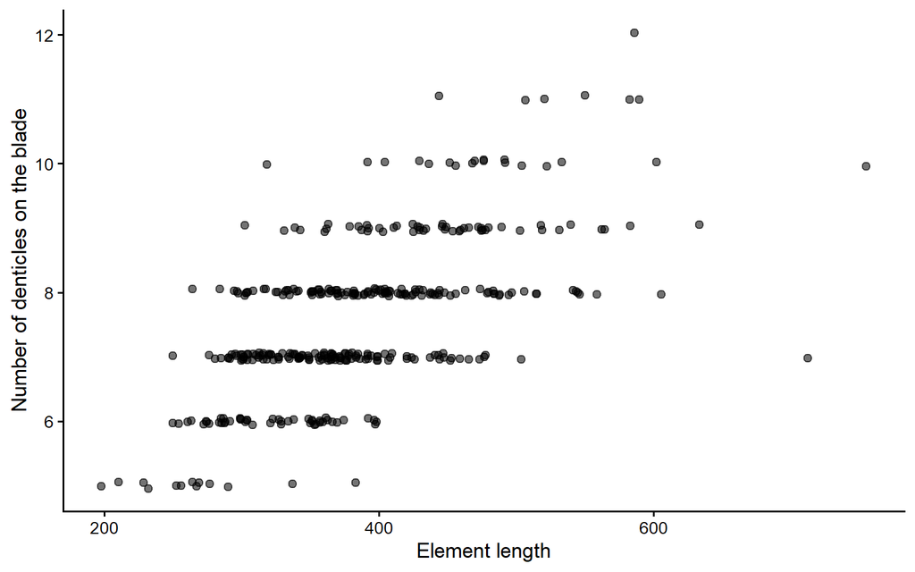

Figure 1: Observed relationship between element length and denticle number. Vertical jitter is used only to reveal overlapping observations; the original values are used in all models.

```r
plot_raw <- ggplot(
  dat,
  aes(
    x = Length,
    y = Denticles
  )
) +
  geom_point(
    position = position_jitter(
      width = 0,
      height = 0.06,
      seed = 123
    ),
    size = 2.1,
    alpha = 0.55
  ) +
  labs(
    x = "Element length",
    y = "Number of denticles on the blade"
  ) +
  theme_classic(
    base_size = 13
  )

plot_raw
```

The exploratory plot should be examined for three potential regions:

1. a steep increase among the smallest elements;
2. a shallower increase across intermediate sizes;
3. an approximately horizontal relationship among the largest elements.

These visual impressions are not used as proof of separate phases. They motivate the formal comparison of models with zero, one, and two breakpoints.

# 7 Model fitting

## 7.1 Linear model

**Show R code**

```r
model_linear <- lm(
  Denticles ~ Length,
  data = dat
)

linear_coef <- coef(model_linear)

linear_intercept <- unname(
  linear_coef["(Intercept)"]
)

linear_slope <- unname(
  linear_coef["Length"]
)

linear_table <- data.frame(
  Term = rownames(
    summary(model_linear)$coefficients
  ),
  summary(model_linear)$coefficients,
  row.names = NULL,
  check.names = FALSE
)

names(linear_table) <- c(
  "Term",
  "Estimate",
  "Standard error",
  "t",
  "p"
)

knitr::kable(
  linear_table,
  digits = c(0, 6, 6, 3, 5),
  caption = "Coefficients of the simple linear regression."
)
```

Coefficients of the simple linear regression.

| Term | Estimate | Standard error | t | p |
| --- | --- | --- | --- | --- |
| (Intercept) | 3.845722 | 0.241875 | 15.900 | 0 |
| Length | 0.009714 | 0.000613 | 15.835 | 0 |

The fitted linear equation is:

[ = 3.8457 + 0.009714. ]

An increase of 100 length units is associated with an average increase of **0.97 denticles** under the assumption of a constant slope.

## 7.2 Helper functions for segmented models

The fitting procedure tests several initial breakpoint values. This reduces dependence on a single numerical starting point. For the three-line model, combinations producing very small segments are excluded.

**Show R code**

```r
fit_one_breakpoint <- function(
  base_model,
  data,
  starting_values,
  n_boot = 10
) {
  attempts <- lapply(
    starting_values,
    function(initial_psi) {
      try(
        segmented::segmented(
          obj = base_model,
          seg.Z = ~ Length,
          psi = list(
            Length = initial_psi
          ),
          control = segmented::seg.control(
            display = FALSE,
            it.max = 300,
            n.boot = n_boot,
            seed = 123
          )
        ),
        silent = TRUE
      )
    }
  )

  valid <- Filter(
    function(x) {
      !inherits(
        x,
        "try-error"
      )
    },
    attempts
  )

  if (length(valid) == 0) {
    stop(
      "No valid one-breakpoint model converged."
    )
  }

  model_aic <- vapply(
    valid,
    AIC,
    numeric(1)
  )

  valid[[which.min(model_aic)]]
}


fit_two_breakpoints <- function(
  base_model,
  data,
  starting_pairs,
  minimum_segment_n = 20,
  n_boot = 10
) {
  attempts <- lapply(
    starting_pairs,
    function(initial_psi) {
      fit <- try(
        segmented::segmented(
          obj = base_model,
          seg.Z = ~ Length,
          psi = list(
            Length = initial_psi
          ),
          control = segmented::seg.control(
            display = FALSE,
            it.max = 300,
            n.boot = n_boot,
            seed = 123
          )
        ),
        silent = TRUE
      )

      if (
        inherits(
          fit,
          "try-error"
        )
      ) {
        return(NULL)
      }

      estimated_breakpoints <- sort(
        as.numeric(
          fit$psi[, "Est."]
        )
      )

      if (
        length(estimated_breakpoints) != 2 ||
        any(!is.finite(estimated_breakpoints))
      ) {
        return(NULL)
      }

      segment_n <- c(
        sum(
          data$Length <= estimated_breakpoints[1]
        ),
        sum(
          data$Length > estimated_breakpoints[1] &
            data$Length <= estimated_breakpoints[2]
        ),
        sum(
          data$Length > estimated_breakpoints[2]
        )
      )

      if (
        any(segment_n < minimum_segment_n)
      ) {
        return(NULL)
      }

      fit
    }
  )

  valid <- Filter(
    Negate(is.null),
    attempts
  )

  if (length(valid) == 0) {
    stop(
      paste0(
        "No valid two-breakpoint model was retained after testing ",
        length(starting_pairs),
        " starting pairs. This can occur if the fits fail to converge ",
        "or if a fitted solution leaves fewer than ",
        minimum_segment_n,
        " observations in one of the three segments."
      )
    )
  }

  model_aic <- vapply(
    valid,
    AIC,
    numeric(1)
  )

  valid[[which.min(model_aic)]]
}
```

## 7.3 Broken-stick model with two lines

**Show R code**

```r
one_break_starting_values <- unique(
  as.numeric(
    quantile(
      dat$Length,
      probs = c(
        0.20,
        0.30,
        0.40,
        0.50,
        0.60,
        0.70,
        0.80
      ),
      na.rm = TRUE
    )
  )
)

model_broken_2 <- fit_one_breakpoint(
  base_model = model_linear,
  data = dat,
  starting_values = one_break_starting_values,
  n_boot = 10
)
```

## 7.4 Broken-stick model with three lines

The two-breakpoint model is more sensitive to its initial values than the one-breakpoint model. A broad multistart search is therefore used. Candidate starting values are generated from all sufficiently separated pairs of internal quantiles rather than from a short, manually specified list.

**Show R code**

```r
# Generate a broad grid of internal quantiles.
start_quantile_probabilities <- seq(
  0.15,
  0.85,
  by = 0.10
)

start_quantiles <- unique(
  as.numeric(
    quantile(
      dat$Length,
      probs = start_quantile_probabilities,
      na.rm = TRUE
    )
  )
)

# Create every possible pair of quantile-based starting values.
starting_pair_matrix <- t(
  combn(
    start_quantiles,
    2
  )
)

# Remove starting pairs that are too close together.
minimum_starting_separation <-
  0.12 *
  diff(
    range(
      dat$Length
    )
  )

starting_pair_matrix <- starting_pair_matrix[
  (
    starting_pair_matrix[, 2] -
      starting_pair_matrix[, 1]
  ) >= minimum_starting_separation,
  ,
  drop = FALSE
]

if (nrow(starting_pair_matrix) == 0) {
  stop(
    "No sufficiently separated starting pairs could be generated."
  )
}

two_break_starting_pairs <- lapply(
  seq_len(
    nrow(starting_pair_matrix)
  ),
  function(i) {
    as.numeric(
      starting_pair_matrix[i, ]
    )
  }
)

# Require a biologically and statistically meaningful number of
# observations in every fitted segment.
minimum_n_three_line_segment <- max(
  15,
  ceiling(
    0.05 *
      nrow(dat)
  )
)

cat(
  "Number of two-breakpoint starting pairs tested:",
  length(two_break_starting_pairs),
  "\n"
)
```

```
Number of two-breakpoint starting pairs tested: 11
```

**Show R code**

```r
cat(
  "Minimum observations required per fitted segment:",
  minimum_n_three_line_segment,
  "\n"
)
```

```
Minimum observations required per fitted segment: 19
```

**Show R code**

```r
model_broken_3 <- fit_two_breakpoints(
  base_model = model_linear,
  data = dat,
  starting_pairs = two_break_starting_pairs,
  minimum_segment_n = minimum_n_three_line_segment,
  n_boot = 10
)
```

# 8 Extracting slopes, equations, and breakpoints

## 8.1 General extraction function

**Show R code**

```r
extract_segmented_model <- function(
  model,
  model_name
) {
  breakpoints <- sort(
    as.numeric(
      model$psi[, "Est."]
    )
  )

  breakpoint_se <- as.numeric(
    model$psi[
      order(
        model$psi[, "Est."]
      ),
      "St.Err"
    ]
  )

  coefficients <- coef(model)

  base_intercept <- unname(
    coefficients["(Intercept)"]
  )

  base_slope <- unname(
    coefficients["Length"]
  )

  hinge_names <- grep(
    pattern = "^U[0-9]+\\.Length$",
    x = names(coefficients),
    value = TRUE
  )

  hinge_numbers <- as.numeric(
    sub(
      "^U([0-9]+)\\.Length$",
      "\\1",
      hinge_names
    )
  )

  hinge_names <- hinge_names[
    order(hinge_numbers)
  ]

  slope_changes <- unname(
    coefficients[hinge_names]
  )

  slopes <- c(
    base_slope,
    base_slope + cumsum(
      slope_changes
    )
  )

  intercepts <- numeric(
    length(slopes)
  )

  intercepts[1] <- base_intercept

  if (length(breakpoints) >= 1) {
    for (
      j in seq_along(breakpoints)
    ) {
      intercepts[j + 1] <-
        intercepts[j] -
        slope_changes[j] *
        breakpoints[j]
    }
  }

  equations <- data.frame(
    Model = model_name,
    Segment = paste(
      "Line",
      seq_along(slopes)
    ),
    Intercept = intercepts,
    Slope = slopes
  )

  breakpoint_y <- vapply(
    seq_along(breakpoints),
    function(j) {
      intercepts[j] +
        slopes[j] *
        breakpoints[j]
    },
    numeric(1)
  )

  breakpoint_table <- data.frame(
    Model = model_name,
    Breakpoint = seq_along(
      breakpoints
    ),
    Length = breakpoints,
    Denticles = breakpoint_y,
    Standard_error = breakpoint_se,
    CI_95_lower = breakpoints +
      qnorm(0.025) *
      breakpoint_se,
    CI_95_upper = breakpoints +
      qnorm(0.975) *
      breakpoint_se
  )

  list(
    equations = equations,
    breakpoints = breakpoint_table
  )
}
```

## 8.2 Extracted parameters

**Show R code**

```r
two_line_results <- extract_segmented_model(
  model_broken_2,
  "Broken-stick: 2 lines"
)

three_line_results <- extract_segmented_model(
  model_broken_3,
  "Broken-stick: 3 lines"
)

two_line_equations <-
  two_line_results$equations

two_line_breakpoints <-
  two_line_results$breakpoints

three_line_equations <-
  three_line_results$equations

three_line_breakpoints <-
  three_line_results$breakpoints

knitr::kable(
  two_line_equations,
  digits = 6,
  caption = "Equations of the two-line broken-stick model."
)
```

Equations of the two-line broken-stick model.

| Model | Segment | Intercept | Slope |
| --- | --- | --- | --- |
| Broken-stick: 2 lines | Line 1 | 3.37796 | 0.011009 |
| Broken-stick: 2 lines | Line 2 | 9.24582 | -0.000079 |

**Show R code**

```r
knitr::kable(
  two_line_breakpoints,
  digits = 3,
  caption = "Breakpoint of the two-line broken-stick model."
)
```

Breakpoint of the two-line broken-stick model.

| Model | Breakpoint | Length | Denticles | Standard_error | CI_95_lower | CI_95_upper |
| --- | --- | --- | --- | --- | --- | --- |
| Broken-stick: 2 lines | 1 | 529.253 | 9.204 | 28.433 | 473.526 | 584.981 |

**Show R code**

```r
knitr::kable(
  three_line_equations,
  digits = 6,
  caption = "Equations of the three-line broken-stick model."
)
```

Equations of the three-line broken-stick model.

| Model | Segment | Intercept | Slope |
| --- | --- | --- | --- |
| Broken-stick: 3 lines | Line 1 | -0.05861 | 0.022942 |
| Broken-stick: 3 lines | Line 2 | 3.79527 | 0.010004 |
| Broken-stick: 3 lines | Line 3 | 8.76801 | 0.000660 |

**Show R code**

```r
knitr::kable(
  three_line_breakpoints,
  digits = 3,
  caption = "Breakpoints of the three-line broken-stick model."
)
```

Breakpoints of the three-line broken-stick model.

| Model | Breakpoint | Length | Denticles | Standard_error | CI_95_lower | CI_95_upper |
| --- | --- | --- | --- | --- | --- | --- |
| Broken-stick: 3 lines | 1 | 297.862 | 6.775 | 18.735 | 261.143 | 334.581 |
| Broken-stick: 3 lines | 2 | 532.174 | 9.119 | 34.824 | 463.920 | 600.428 |

# 9 Interpretation of the fitted trajectories

## 9.1 Two-line model

The one-breakpoint model estimates a transition at an element length of **529.25**, where the expected denticle number is **9.20**. Its approximate 95% confidence interval extends from **473.53 to 584.98**.

Before the breakpoint, denticle number changes by approximately **1.10 denticles per 100 length units**. After the breakpoint, the expected change is **-0.008 denticles per 100 length units**, which is effectively zero.

This model therefore represents:

1. a juvenile phase of denticle addition;
2. an adult phase with a denticle-number plateau.

## 9.2 Three-line model

The model with two breakpoints estimates transitions at:

- **297.86 length units**, with approximately **6.78 denticles**;
- **532.17 length units**, with approximately **9.12 denticles**.

The corresponding approximate 95% confidence intervals are:

- first breakpoint: **261.14–334.58**;
- second breakpoint: **463.92–600.43**.

The estimated rates of change are:

- first phase: **2.29 denticles per 100 length units**;
- second phase: **1.00 denticles per 100 length units**;
- third phase: **0.066 denticles per 100 length units**.

The three-line model therefore describes a progressive reduction in denticle-addition rate:

1. **early juvenile phase:** rapid denticle addition;
2. **late juvenile/subadult phase:** continued but slower denticle addition;
3. **adult phase:** near-complete stabilisation of denticle number.

# 10 Model comparison

## 10.1 Calculation of model-selection statistics

**Show R code**

```r
get_model_statistics <- function(
  model,
  model_name,
  response
) {
  model_log_likelihood <- logLik(
    model
  )

  k <- attr(
    model_log_likelihood,
    "df"
  )

  n <- nobs(
    model
  )

  model_aic <- AIC(
    model
  )

  model_aicc <- if (
    n > k + 1
  ) {
    model_aic +
      (
        2 * k * (k + 1)
      ) /
      (
        n - k - 1
      )
  } else {
    NA_real_
  }

  residual_values <- residuals(
    model
  )

  rss <- sum(
    residual_values^2
  )

  rmse <- sqrt(
    mean(
      residual_values^2
    )
  )

  total_ss <- sum(
    (
      response -
        mean(response)
    )^2
  )

  r_squared <- 1 -
    rss / total_ss

  data.frame(
    Model = model_name,
    N = n,
    K = k,
    logLik = as.numeric(
      model_log_likelihood
    ),
    AIC = model_aic,
    AICc = model_aicc,
    BIC = BIC(model),
    RMSE = rmse,
    R_squared = r_squared
  )
}

model_comparison <- rbind(
  get_model_statistics(
    model_linear,
    "Linear",
    dat$Denticles
  ),
  get_model_statistics(
    model_broken_2,
    "Broken-stick: 2 lines",
    dat$Denticles
  ),
  get_model_statistics(
    model_broken_3,
    "Broken-stick: 3 lines",
    dat$Denticles
  )
)

model_comparison$Delta_AIC <-
  model_comparison$AIC -
  min(
    model_comparison$AIC
  )

model_comparison$AIC_weight <-
  exp(
    -0.5 *
      model_comparison$Delta_AIC
  ) /
  sum(
    exp(
      -0.5 *
        model_comparison$Delta_AIC
    )
  )

model_comparison$Delta_AICc <-
  model_comparison$AICc -
  min(
    model_comparison$AICc
  )

model_comparison$AICc_weight <-
  exp(
    -0.5 *
      model_comparison$Delta_AICc
  ) /
  sum(
    exp(
      -0.5 *
        model_comparison$Delta_AICc
    )
  )

model_comparison$Delta_BIC <-
  model_comparison$BIC -
  min(
    model_comparison$BIC
  )

model_comparison <- model_comparison[
  order(
    model_comparison$AICc
  ),
]

rownames(model_comparison) <- NULL

knitr::kable(
  model_comparison,
  digits = 4,
  caption = "Comparison of the three candidate models."
)
```

Comparison of the three candidate models.

| Model | N | K | logLik | AIC | AICc | BIC | RMSE | R_squared | Delta_AIC | AIC_weight | Delta_AICc | AICc_weight | Delta_BIC |
| --- | --- | --- | --- | --- | --- | --- | --- | --- | --- | --- | --- | --- | --- |
| Broken-stick: 3 lines | 374 | 7 | -500.242 | 1014.48 | 1014.79 | 1041.95 | 0.9218 | 0.4325 | 0.0000 | 0.8038 | 0.0000 | 0.7921 | 4.9977 |
| Broken-stick: 2 lines | 374 | 5 | -503.667 | 1017.33 | 1017.50 | 1036.96 | 0.9303 | 0.4220 | 2.8508 | 0.1932 | 2.7078 | 0.2045 | 0.0000 |
| Linear | 374 | 3 | -509.833 | 1025.67 | 1025.73 | 1037.44 | 0.9458 | 0.4026 | 11.1815 | 0.0030 | 10.9404 | 0.0033 | 0.4822 |

## 10.2 AICc results

The three-line broken-stick model has the lowest AICc:

- three lines: **1014.79**;
- two lines: **1017.50**;
- linear: **1025.73**.

The two-line model has (=)**2.71**, whereas the linear model has (=)**10.94**.

The AICc weights are:

- three-line broken-stick: **0.792**;
- two-line broken-stick: **0.205**;
- linear: **0.003**.

Thus, the linear model receives essentially no support relative to either segmented model. The candidate set strongly supports at least one ontogenetic change in slope.

The comparison between the two segmented models is more nuanced. The three-line model improves AICc by **2.71 units** relative to the two-line model. This constitutes meaningful, but not overwhelming, evidence for the first additional breakpoint.

## 10.3 Fit improvement

Compared with the two-line model, the three-line model:

- increases (R^2) by **1.05 percentage points**;
- reduces RMSE by approximately **0.91%**.

The additional early breakpoint therefore improves the description of the smallest elements, but the increase in overall explanatory and predictive performance is modest.

## 10.4 BIC results

BIC applies a stronger complexity penalty. The model with the lowest BIC is **Broken-stick: 2 lines**.

The three-line model has (=)**5.00**. Thus, unlike AICc, BIC does not favour the most complex model. This discrepancy indicates that the evidence for three phases depends on the balance assigned to goodness of fit versus parsimony.

**Main model-selection conclusion**

The results reject a single linear ontogenetic trajectory. Both segmented models provide a substantially better description of the data.

AICc favours the **three-line model**, supporting a possible early juvenile, late juvenile/subadult, and adult sequence. However, its advantage over the two-line model is moderate rather than decisive, and BIC favours the more parsimonious two-line model.

The safest conclusion is therefore:

- there is strong evidence for an ontogenetic reduction in the rate of denticle addition;
- there is clear evidence for an adult plateau;
- there is suggestive, but not definitive, evidence for an additional transition within the juvenile portion of the trajectory.

# 11 Graphical comparison

## 11.1 Prediction grid

**Show R code**

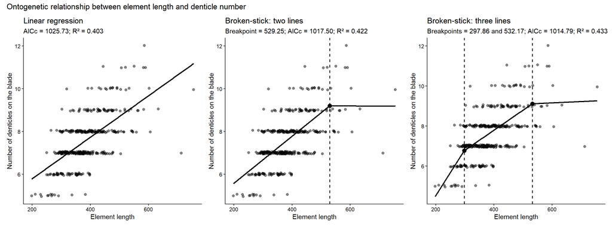

Figure 2: Comparison of the linear, two-line broken-stick, and three-line broken-stick models. Vertical dashed lines indicate estimated breakpoints.

```r
base_points <- list(
  geom_point(
    position = position_jitter(
      width = 0,
      height = 0.06,
      seed = 123
    ),
    size = 1.8,
    alpha = 0.48
  ),
  theme_classic(
    base_size = 11
  ),
  labs(
    x = "Element length",
    y = "Number of denticles on the blade"
  )
)

plot_linear <- ggplot(
  dat,
  aes(
    x = Length,
    y = Denticles
  )
) +
  base_points +
  geom_line(
    data = prediction_grid,
    aes(
      x = Length,
      y = Linear
    ),
    inherit.aes = FALSE,
    linewidth = 1
  ) +
  labs(
    title = "Linear regression",
    subtitle = sprintf(
      "AICc = %.2f; R² = %.3f",
      row_linear$AICc,
      row_linear$R_squared
    )
  )

plot_two <- ggplot(
  dat,
  aes(
    x = Length,
    y = Denticles
  )
) +
  base_points +
  geom_line(
    data = prediction_grid,
    aes(
      x = Length,
      y = Broken_stick_2lines
    ),
    inherit.aes = FALSE,
    linewidth = 1
  ) +
  geom_vline(
    xintercept = bp2,
    linetype = "dashed",
    linewidth = 0.65
  ) +
  geom_point(
    data = data.frame(
      Length = bp2,
      Denticles = bp2_y
    ),
    aes(
      x = Length,
      y = Denticles
    ),
    inherit.aes = FALSE,
    size = 3
  ) +
  labs(
    title = "Broken-stick: two lines",
    subtitle = sprintf(
      "Breakpoint = %.2f; AICc = %.2f; R² = %.3f",
      bp2,
      row_two$AICc,
      row_two$R_squared
    )
  )

plot_three <- ggplot(
  dat,
  aes(
    x = Length,
    y = Denticles
  )
) +
  base_points +
  geom_line(
    data = prediction_grid,
    aes(
      x = Length,
      y = Broken_stick_3lines
    ),
    inherit.aes = FALSE,
    linewidth = 1
  ) +
  geom_vline(
    xintercept = c(
      bp3_1,
      bp3_2
    ),
    linetype = "dashed",
    linewidth = 0.65
  ) +
  geom_point(
    data = data.frame(
      Length = c(
        bp3_1,
        bp3_2
      ),
      Denticles = c(
        bp3_y1,
        bp3_y2
      )
    ),
    aes(
      x = Length,
      y = Denticles
    ),
    inherit.aes = FALSE,
    size = 3
  ) +
  labs(
    title = "Broken-stick: three lines",
    subtitle = sprintf(
      "Breakpoints = %.2f and %.2f; AICc = %.2f; R² = %.3f",
      bp3_1,
      bp3_2,
      row_three$AICc,
      row_three$R_squared
    )
  )

combined_plot <- (
  plot_linear |
    plot_two |
    plot_three
) +
  patchwork::plot_annotation(
    title = paste(
      "Ontogenetic relationship between element length",
      "and denticle number"
    )
  )

combined_plot
```

**Show R code**

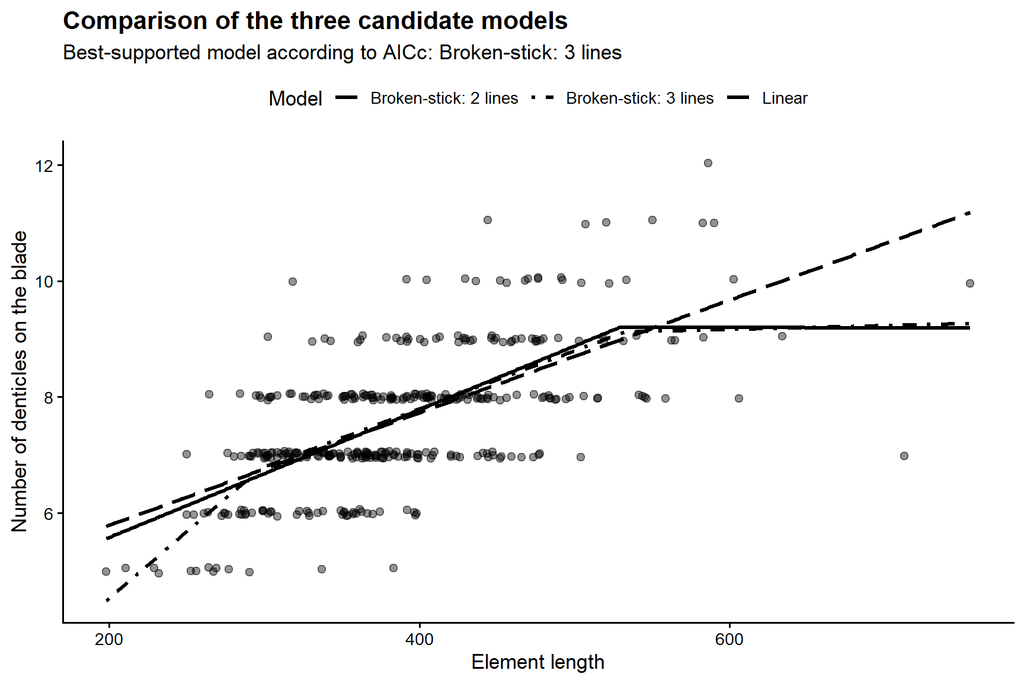

Figure 3: Direct comparison of predictions from the three candidate models.

```r
overlay_plot <- ggplot(
  dat,
  aes(
    x = Length,
    y = Denticles
  )
) +
  geom_point(
    position = position_jitter(
      width = 0,
      height = 0.06,
      seed = 123
    ),
    size = 2,
    alpha = 0.42
  ) +
  geom_line(
    data = comparison_predictions,
    aes(
      x = Length,
      y = Prediction,
      linetype = Model
    ),
    inherit.aes = FALSE,
    linewidth = 1.1
  ) +
  scale_linetype_manual(
    values = c(
      "Linear" = "longdash",
      "Broken-stick: 2 lines" = "solid",
      "Broken-stick: 3 lines" = "dotdash"
    )
  ) +
  labs(
    title = "Comparison of the three candidate models",
    subtitle = paste0(
      "Best-supported model according to AICc: ",
      model_comparison$Model[1]
    ),
    x = "Element length",
    y = "Number of denticles on the blade",
    linetype = "Model"
  ) +
  theme_classic(
    base_size = 13
  ) +
  theme(
    plot.title = element_text(
      face = "bold"
    ),
    legend.position = "top"
  )

overlay_plot
```

## 11.4 Relative AICc support

**Show R code**

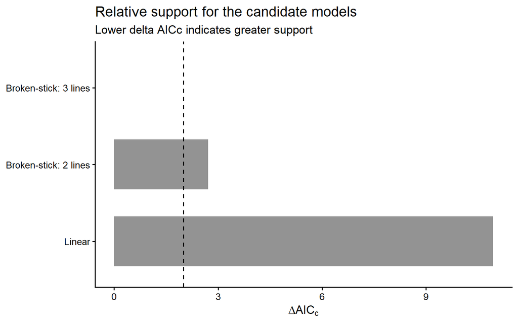

Figure 4: Relative support for the candidate models based on delta AICc. The dashed line at two units marks a commonly used threshold for models with substantial support.

```r
aicc_plot_data <- model_comparison

aicc_plot_data$Model <- factor(
  aicc_plot_data$Model,
  levels = rev(
    model_comparison$Model
  )
)

aicc_plot <- ggplot(
  aicc_plot_data,
  aes(
    x = Delta_AICc,
    y = Model
  )
) +
  geom_col(
    width = 0.65,
    alpha = 0.65
  ) +
  geom_vline(
    xintercept = 2,
    linetype = "dashed",
    linewidth = 0.7
  ) +
  labs(
    title = "Relative support for the candidate models",
    subtitle = "Lower delta AICc indicates greater support",
    x = expression(
      Delta * AIC[c]
    ),
    y = NULL
  ) +
  theme_classic(
    base_size = 13
  )

aicc_plot
```

# 12 Operational ontogenetic phases

The breakpoints of the three-line model can be used to define provisional phases:

**Show R code**

```r
dat$Three_phase_assignment <- cut(
  dat$Length,
  breaks = c(
    -Inf,
    bp3_1,
    bp3_2,
    Inf
  ),
  labels = c(
    "Phase 1: early juvenile",
    "Phase 2: late juvenile / subadult",
    "Phase 3: likely adult"
  ),
  right = TRUE
)

phase_counts <- as.data.frame(
  table(
    dat$Three_phase_assignment
  )
)

names(phase_counts) <- c(
  "Operational phase",
  "N"
)

phase_counts$Percentage <-
  100 *
  phase_counts$N /
  sum(
    phase_counts$N
  )

knitr::kable(
  phase_counts,
  digits = 1,
  caption = "Operational assignment based on the two point estimates from the three-line model."
)
```

Operational assignment based on the two point estimates from the three-line model.

| Operational phase | N | Percentage |
| --- | --- | --- |
| Phase 1: early juvenile | 40 | 10.7 |
| Phase 2: late juvenile / subadult | 315 | 84.2 |
| Phase 3: likely adult | 19 | 5.1 |

This classification is descriptive and circular: the same variables are used both to estimate and to apply the breakpoints. It must not be treated as an independently validated age classification.

A conservative interpretation should consider uncertainty around both breakpoints. Specimens close to either interval should be regarded as transitional rather than assigned categorically.

# 13 Residual diagnostics

**Show R code**

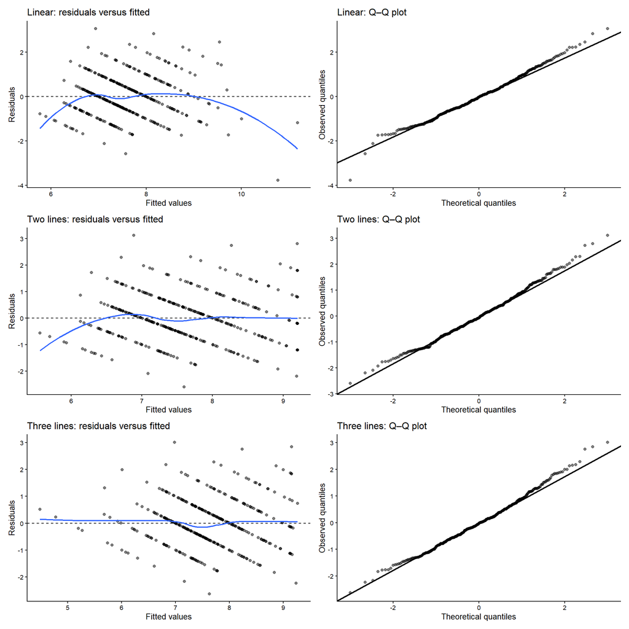

Figure 5: Residual and Q–Q diagnostics for the three candidate models.

```r
diagnostic_plot <- (
  make_residual_plot(
    model_linear,
    "Linear: residuals versus fitted"
  ) |
    make_qq_plot(
      model_linear,
      "Linear: Q–Q plot"
    )
) /
  (
    make_residual_plot(
      model_broken_2,
      "Two lines: residuals versus fitted"
    ) |
      make_qq_plot(
        model_broken_2,
        "Two lines: Q–Q plot"
      )
  ) /
  (
    make_residual_plot(
      model_broken_3,
      "Three lines: residuals versus fitted"
    ) |
      make_qq_plot(
        model_broken_3,
        "Three lines: Q–Q plot"
      )
  )

diagnostic_plot
```

Because denticle number is a count variable with a limited number of possible values, banding and some departure from continuous Gaussian residuals are expected. The diagnostics should be examined for:

- strong residual curvature;
- non-constant residual variance;
- influential observations;
- pronounced departures from normality;
- whether the first breakpoint is driven by only a few small elements.

# 14 Biological interpretation

## 14.1 Evidence for an adult plateau

The strongest biological result is the stabilisation of denticle number at large element sizes. Both segmented models estimate the final change at approximately the same length and predict a final slope close to zero.

This agreement indicates that the adult plateau is not dependent on whether one or two breakpoints are fitted. The data support a phase in which conodont elements continue to increase in length after the principal denticulation pattern has been established.

## 14.2 Possible subdivision of juvenile growth

The three-line model divides the increasing portion of the trajectory into two phases:

1. rapid denticle addition among the smallest elements;
2. slower but continued addition at intermediate sizes.

This pattern could represent a distinction between early juveniles and late juveniles or subadults. The first breakpoint occurs at approximately **297.86**, where the expected number is **6.78 denticles**.

However, this first transition is less secure than the adult transition because:

- the AICc advantage over the two-line model is moderate;
- BIC does not support the additional complexity;
- the first slope is estimated from the smallest portion of the size distribution;
- a few small specimens may have strong leverage;
- no independent maturity criterion has yet been incorporated.

## 14.3 Can three ontogenetic groups be distinguished?

The analysis provides a stronger basis for recognising **growth phases** than for assigning each individual to a discrete class.

The following interpretation is justified:

- **small elements:** likely early juveniles, with rapid denticle addition;
- **intermediate elements:** likely later juveniles or subadults, with slower denticle addition;
- **large elements:** likely adults, with a stable denticle number.

The following stronger claim is not yet justified:

> Element length and denticle number alone unambiguously separate every specimen into juvenile, subadult, and adult groups.

Substantial overlap remains in denticle number, particularly around the breakpoints. Classification should therefore be probabilistic or accompanied by an uncertain/transitional category.

# 15 Limitations and recommended follow-up analyses

## 15.1 Count nature of denticle number

Denticle number is a count response. Gaussian segmented regression is useful for describing the mean pattern, but the analysis should be checked using a segmented Poisson or negative-binomial model, particularly if residual variance changes with fitted values.

## 15.2 Breakpoint uncertainty

The second breakpoint has a relatively broad confidence interval. This means that the exact onset of the adult plateau is uncertain even though the existence of the plateau is well supported.

Bootstrap confidence intervals should be preferred over simple Wald intervals for final publication.

## 15.3 Model-selection uncertainty

The AICc weights indicate that the two-line model still retains non-negligible support. Biological conclusions should therefore acknowledge model-selection uncertainty rather than treating the three-line model as uniquely correct.

Potential approaches include:

- reporting both segmented models;
- model averaging of predictions;
- cross-validation;
- parametric bootstrap comparison;
- testing whether the first breakpoint replicates in an independent sample.

## 15.4 Alternative smooth-growth models

A biological transition may be gradual rather than angular. Useful alternatives include:

- asymptotic saturation curves;
- Gompertz or logistic growth curves;
- generalised additive models;
- segmented count regressions;
- mixture or latent-class models if the research question specifically concerns discrete cohorts.

## 15.5 Independent ontogenetic validation

The most important next step is to compare the candidate thresholds with independent indicators of maturity, such as:

- changes in element robustness or proportions;
- denticle shape, size, or spacing;
- histological growth increments;
- wear or functional modification;
- independently recognised juvenile or adult morphologies.